# Learning Python

How many of you know one programming language? Two?

How many of you consider yourselves "coders"? or "programmers"? or "hackers"? or "software engineers"?

# Quiz:

Ratio, Interval, ... Ordinal, or Nominal?

### Why?

### Note: Data are *everywhere*.

# Learning any programming language in 4 easy steps

- Pick a task you know how to solve in some programming language (e.g. binary search)
- Write a solution in this new language
- Review it to see how you could make it more "idiomatic" (called "pythonic" in the specific case of python)
- Rinse. Repeat.

# Once you learn a second language, you begin to have a sense of how languages are organized

- Data
  - Variables
  - Constants
  - Assignment or binding
  - Objects (maybe)
- Code
  - Arithmetic
  - Decisions (`if`, et al)
  - Control structures (`for` or `while` loops, etc.)
  - Function calls

# Very few languages will break this mold

# Python basics

```python
import math

# Variables and arithmetic
x = 5
print 'x = %d' % (x + 5)

y = 5.6 #3.14159265
print y

y = y + x
print y

print "Hello, world"

print '%d %.2f %s %r' % (x, round(y), " Hello, world", "Hello, world  ")
```

```
x = 10
5.6
10.6
Hello, world
5 11.00  Hello, world 'Hello, world  '
```

# What do we notice here?

- "infix" syntax for arithmetic (`algol`-like)
- no explicit type definitions in code (dynamic typing; types are resolved at runtime)
- `print` is a way to print something to the screen. (Curiously, it has no parentheses)

```python
#  It groups how you'd expect too.
5 + 4 * 2 != 18
```

```
True
```

# Other data types

```python
l = [1,2,3]
d = {
    'name': 'Introduction to Data Science',
    'number': 601,
    'dept': 'DATA',
    'students': [ { 'name': 'John Smith',
                    'id': 12345
                  }
                ],
    'instructor': { 'name': 'James Kukla'}
}
s = {2,3,2, "Hello"}
b = True

print(type(l))
print(type(d))
print(type(s))
print(type(b))

print(s)

print([l, d, s, b])
```

```
<type 'list'>
<type 'dict'>
<type 'set'>
<type 'bool'>
set([2, 3, 'Hello'])
[[1, 2, 3], {'students': [{'name': 'John Smith', 'id': 12345}], 'dept': 'DATA', 'instructor': {'name': 'James Kukla'}, 'name': 'Introduction to Data Science', 'number': 601}, set([2, 3, 'Hello']), True]
```

```python
print(l[0])
key = 'name'
print(d[key])
print(b)

# print(d.keys())
# print(d['instructor']['name'])

# print(dir(d))

# print(d.keys())

print(3 in s)

print('firstname' in d)
```

```
1
Introduction to Data Science
True
True
False
```

# Apparently python supports runtime exceptions 😉

```python
new_id = 'xx12'
try:
    numeric_id = int(new_id)
    print('id checks out')
except ValueError:
    print('Bad id')
except TypeError:
    pass

def min(l):
    pass
```

```
Bad id
```

# Can catch exceptions using `try` and `except` blocks.

# What else do we see there? ... anything structural?

No curly braces for "blocks". Just common indented space.

# More Control Flow

```python
flag = 5
if flag == 0:
    print('zero')
elif flag % 2 == 0:
    print('even')
else:
    print('odd')
```

```
odd
```

# Note the `elif` thing. You get used to it.

# Loops

```python
i = 0
total = 0
n = 123
while i < n:
    i += 1          #  No ++ in python
    total = total + i   # Could have been +=

print(total)
#  ... or ...
print((n*(n+1))/2)  # HT Gauss!

print('sums are equal: %s' % (total == 7626))
```

```
7626
7626
sums are equal: True
```

```python
#  For loops are weirder.  Only a "foreach" -- looping over sequences.
for x in [1,2,3]:
    print(x)

#  How about parallel arrays?
x = [2,4,6]
y = [1,3,5]
for i in range(len(x)):
    print(x[i] + y[i])

#print(range([1,2,3]))


for i, x in enumerate([1,2,3]):
    print('i is %d, x is %r' % (i, x))

enumeration = enumerate([3,4,5])
print(enumeration)
xx = list(enumeration)
```

```
1
2
3
3
7
11
i is 0, x is 1
i is 1, x is 2
i is 2, x is 3
<enumerate object at 0x105736910>
```

```python
PI = 3.14159265
x = [1,2,3,4]
print('len(x) = %d' % len(x))
print('range(len(x)) = %r' % range(len(x)))
```

```
len(x) = 4
range(len(x)) = [0, 1, 2, 3]
```

```python
#  In a more pythonic way, let's skip the intermediate index list and get straight to the list of pairs.
print(x)
print(y)
for (xi, yi) in zip(x, y):
    print(xi, yi)
```

```
[1, 2, 3, 4]
[1, 3, 5]
(1, 1)
(2, 3)
(3, 5)
```

# Whoa.

Note that these have parentheses around them in spots. That's a `tuple` which is kind of like an immutable list.

```python
z = (1, 2, )
print(type(z))
```

```
<type 'tuple'>
```

```python
print (1) == (1,)
print (1) == 1
print (1,) == 1

print (1,)[0]

l = [1,2,3]
print(l)
l[1]= 42
print(l)

t = (1,2,)
t[1] = 42
```

```
False
True
False
1
[1, 2, 3]
[1, 42, 3]
```

```
---------------------------------------------------------------------------
TypeError                                 Traceback (most recent call last)
<ipython-input-12-4668f8a72604> in <module>()
     11
     12 t = (1,2,)
---> 13 t[1] = 42

TypeError: 'tuple' object does not support item assignment
```

# Functions

Functions let you package bits of code that you want to be able to reuse.

We give these *parameters* so that we can make them more useful.

For example, we might write a function called `min` to give us the minimum value in a list.

```python
# Let's try min and max...
def min(l):
    '''Given a list, l, return the smallest value in l'''
    sorted_l = sorted(l)
    return sorted_l[0]

print(min([3,4,1,4,12,0]) == 0)
print(min([-3,4,1,4,12,0]) == -3)

def max(l):
    '''Given a list, l, return the largest value in l'''
    return sorted(l, reverse=True)[0]
print(max([3,4,1,4,12,0]) == 12)
print(max([-3,4,1,4,12,0]) == 12)
```

```
True
True
True
True
```

Let's talk about the arithmetic mean.

- What is it?
- How do we calculate it?

What do we think that will look like in python?

```python
def arithmetic_mean(l):
    '''Compute the arithmetic mean of the list l'''
    total = 0
    for x in l:
        total += x
    return float(total)/len(l)

#  Let's test it
arithmetic_mean([5,10,15]) == 10
```

```
True
```

# How about the median?

- How do we define it?
- What might it look like?

```python
def median(l):
    sorted_l = sorted(l)
    n = len(l)
    midpoint = int(n/2)
    if n % 2 == 1:
        return sorted_l[midpoint]
    else:
        return (sorted_l[midpoint-1] + sorted_l[midpoint])/2.0

print('median for odd length: %r' % (median([2,5,6]) == 5))
print('median for even length: %r' % (median([2,5,6,7]) == 5.5))
```

```
median for odd length: True
median for even length: True
```

# Why `midpoint - 1`? Python indexes from 0.

# What if we want to compute the quartiles? 25%, 50%, and 75%

- The median *is* the 50th percentile
- Knowing what we know about the median, what can we say about the 25th percentile?

```python
def first_quartile(l):
    '''Return the 25th percentile

Note that this is the median of the lower half of the list.
    '''
    sorted_l = sorted(l)
    middle = int(len(sorted_l)/2)
    print "middle=%r, len(l)=%r" % (middle, len(l))
    return median(sorted_l[0:middle])
print('First quartile test: %r' % (first_quartile([1,2,3,4,5,6,7,8,9,10]) == 3))

def third_quartile(l):
    sorted_l = sorted(l)
    middle = int(len(sorted_l)/2)
    print "middle=%r, len(l)=%r" % (middle, len(l))
    return median(sorted_l[middle:])
print('Third quartile test: %r' % (third_quartile([1,2,3,4,5,6,7,8,9,10]) == 8))
third_quartile([1,2,342,231, 6])

l = range(0,10)
print l

print 'min=%r, 25%%=%r, 50%%=%r, 75%%=%r, max=%r' % (min(l), first_quartile(l), median(l), third_quartile(l), max(l))
```

```
middle=5, len(l)=10
First quartile test: True
middle=5, len(l)=10
Third quartile test: True
middle=2, len(l)=5
[0, 1, 2, 3, 4, 5, 6, 7, 8, 9]
middle=5, len(l)=10
middle=5, len(l)=10
min=0, 25%=2, 50%=4.5, 75%=7, max=9
```

```python
help(sorted)
```

```
Help on built-in function sorted in module __builtin__:

sorted(...)
    sorted(iterable, cmp=None, key=None, reverse=False) --> new sorted list
```

```python
#  Let's write map and filter...
def map(f, l):
    '''Given function, f, and list, l, return [f(l[0]), f(l[1]), ...]'''
    result = []
    for x in l:
        result.append(f(x))
    return result

def plus5(x):
    return x + 5

print map(plus5, [1,2,3])
print map(lambda x: x+6, [1,2,3])
```

```
[6, 7, 8]
[7, 8, 9]
```

```python
sum(map(lambda x: x+6, [1,2,3]))
```

```
24
```

```python
#  But there's a more pythonic way...
def map(f, l):
    return [f(x) for x in l]
map(plus5, [4,5,6])
```

```
[9, 10, 11]
```

This sweet thing is called a "list comprehension"

... it defines a list "implicitly" (based on a rule) rather than explicitly.

```python
def filter(f, l):
    return [x for x in l if f(x) == True]
filter(lambda x: x % 2 == 0, range(10))

print range(10), [x for x in range(10) if x % 2 == 0]
```

```
[0, 1, 2, 3, 4, 5, 6, 7, 8, 9] [0, 2, 4, 6, 8]
```

# Intermission

Let's talk a little about IPython Notebooks

- Interactive interface for exploring with code
- Provides a number of cool facilities...

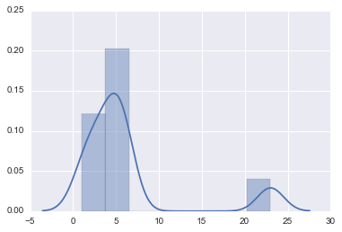

```python
# Integrated visualization (e.g. `%matplotlib inline`)
%matplotlib inline
dataset = [2, 5, 3, 6, 1, 23, 4, 5, 6]

import seaborn as sns
sns.set(color_codes=True)  # boilerplate

sns.distplot(dataset)
```

```python
#  Integrated timing functions...
import random
data = [random.randint(1,10) for x in range(100)]
%timeit median(data)
```

```
10000 loops, best of 3: 25.5 µs per loop
```

```python
#  An integrated profiler for seeing where code spends its time
import random
data = [random.randint(1, 10) for x in range(100)]
print len(data * 10000)
%prun median(data * 10000)
```

```
1000000
```

# And more...

- An interactive debugger that works *after* an error is thrown (%debug)

# Back to Python

- Python includes a large set of built-in libraries

```python
#  Import the Counter object type from the collections library
from collections import Counter

#  Import the random library
import random

#  Generate a dataset using a list comprehension.  We pick a random int on [1,10] for each of 100 elements.
population = [random.randint(1,10) for x in range(100)]

#  Now we can count them
counter = Counter(population)

#  And fetch the elements sorted by their popularity
counter.most_common()
```

```
[(5, 15),
 (2, 13),
 (6, 12),
 (3, 10),
 (7, 10),
 (8, 10),
 (9, 10),
 (1, 9),
 (4, 7),
 (10, 4)]
```

```
[(5, 15), (2, 13), (6, 12), (3, 10), (7, 10), (8, 10), (9, 10), (1, 9), (4, 7), (10, 4)]
```

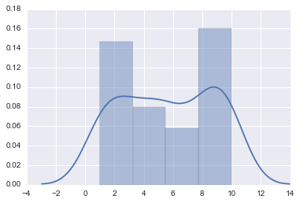

```python
#  If we sort this by value, not count, we get something like a histogram
from operator import itemgetter
print(sorted(counter.most_common(), key=itemgetter(1), reverse=True))

sns.distplot(data)
```

# That's cool. Can we draw a real histogram?

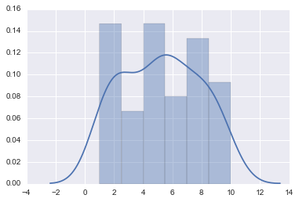

```python
%matplotlib inline
import seaborn as sns
sns.set(color_codes=True)  # boilerplate

sns.distplot(population)
```

```python
sns.distplot?
```